# Assignment 1

## 16.31:

```r
MPGdata <- read_csv('ex16-31mpg20.csv') # read the file of MPGs
mpgMPG <-MPGdata$MPG
#find sample size
sampleSize <-length(mpgMPG)
# find s of sample part a).
sampleS <-sd(mpgMPG)
# for part b
MuOfS <- one.boot(mpgMPG,function(x) sd(x),R=10000)
SEofSDs <- sd(MuOfS$t)
# used for part d
#plot.bt(MuOfS)
```

## 16.50:

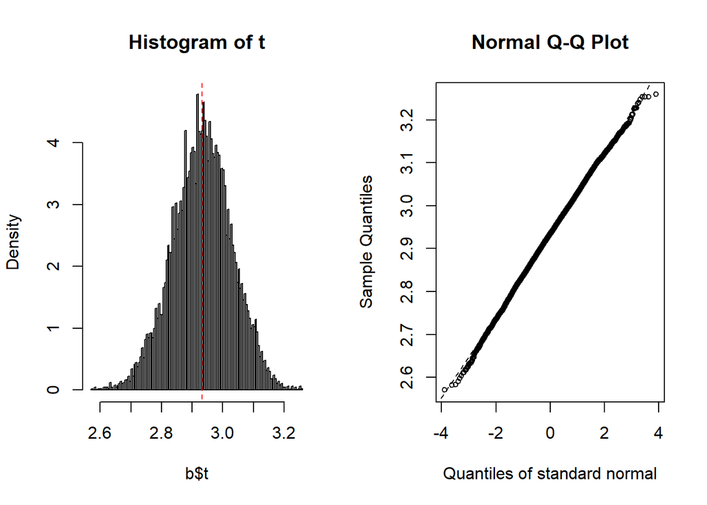

```r
GPA50 <- read_csv('ex16-50gpa.csv') # read the file of MPGs
GPA50GPAF <-filter(GPA50,sex=='2')
MuOfS <- one.boot(GPA50GPAF$GPA,function(x) mean(x),R=10000)
SDofMuOfS <- sd(MuOfS$t)

plot.bt(MuOfS)
```

- a). The bootstrap distribution of means is skewed slightly to the left. This means that t distribution can be off on the lower end. Otherwise, the graph appears normally distributed. At 0, the bias is small. T distribution can be used if the bias is small and the data is normally distributed. Since Student’s distribution confidence intervals do not make up for bias or skewness, student’s distribution should not be used if percentile and normal t intervals differ too much, data is skewed or bias is significant. With percentile distribution correcting for skewness, we can use the percentile distribution. BCa corrects for bias and skewness. Because the difference between t and percentile intervals is small and we don’t have bias, it is fine to use percentile confidence interval.
- b). The 95% confidence interval using normal t-distribution is ( 2.743, 3.121); percentile based interval is 2.738, 3.117); bca interval is 2.733, 3.117). T distribution reaches out the same amount on both sides to find the 95% confidence interval because we have an extended tail on the left, it does not reach out far enough on the left and goes too far to the right. Percentile distribution corrects for the extended left tail and reaches further to the left but does not over extend to the right of the parameter. Yet if we have have a bias, percentile will not correct for it.

## 16.52:

```r
GPA52 <- read_csv('ex16-52gpa.csv') # read the file of MPGs
GPA52GPAs <-GPA52$GPA #vector of GPAs
GPA52HighSchoolMathGrades <-GPA52$HSM #vector of highschool math grades

# part b
#ggplot(GPA52, aes(x=GPA, y = HSM)) + geom_point()
```

- a). The distributions of high school GPAs and high school math grades are unimodal, skewed to the left with no outliers present.
- b). There is a weak positive associate between HSM and GPA but the association is not linear.
- c).

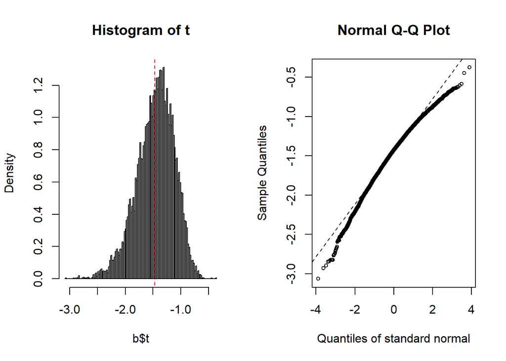

```r
bootStrappedRelatnHSMGPA <- two.bt(GPA52$GPA,GPA52$HSM,FUN=var,R=10000,ratio=FALSE)
plot.bt(bootStrappedRelatnHSMGPA)
```

```r
#boot.ci(bootStrappedRelatnHSMGPA)
```

16.66:

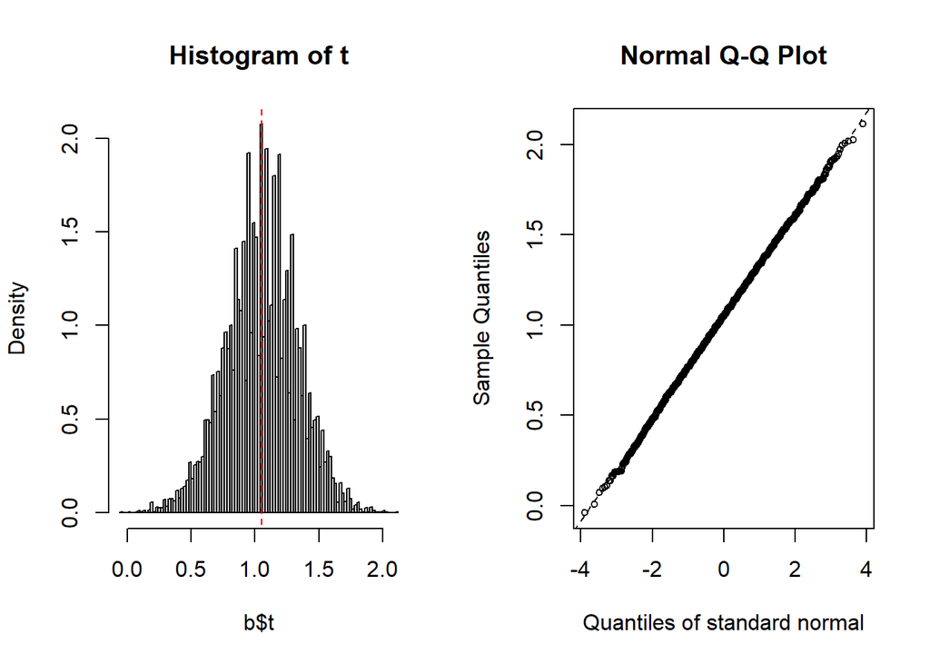

```r
brandPR <- read_csv('ex16-66brandpr.csv') # read the file of brandpr data
# select primed group
brandPRPrimed <- filter(brandPR, Primed== 'Yes')
brandPRNotPrimed <- filter(brandPR, Primed== 'No')
b <- two.boot(brandPRPrimed$Preference,brandPRNotPrimed$Preference,FUN=function(x) mean(x),R=10000)
plot.bt(b)
```